# Assignment09

# end

## Problem 2

The pima dataset consists of 768 female Pima Indians. We want to predict the diabetes test result from the other predictors To get the data set, copy and paste the r command: data(pima,package=“faraway”). Use 70% of the data for train data set and use remaining data (30% of data) for test data set (use set.seed(456)). (25 points, 5 points each)

a-) Fit a tree model on the train data set and evaluate the performance on the test data set. (5 Points)

Step 1: Load the data set and remove any missing values.

Step 2: Analyse the data- look for multicollinearity.

Step3: Split into train and test data

```r
library(faraway)

data(pima, package = "faraway")

head(pima)
```

|  | pregnant | glucose | diastolic | triceps | insulin | bmi | diabetes | age | test |
| --- | --- | --- | --- | --- | --- | --- | --- | --- | --- |
| 1 | 6 | 148 | 72 | 35 | 0 | 33.6 | 0.627 | 50 | 1 |
| 2 | 1 | 85 | 66 | 29 | 0 | 26.6 | 0.351 | 31 | 0 |
| 3 | 8 | 183 | 64 | 0 | 0 | 23.3 | 0.672 | 32 | 1 |
| 4 | 1 | 89 | 66 | 23 | 94 | 28.1 | 0.167 | 21 | 0 |
| 5 | 0 | 137 | 40 | 35 | 168 | 43.1 | 2.288 | 33 | 1 |
| 6 | 5 | 116 | 74 | 0 | 0 | 25.6 | 0.201 | 30 | 0 |

```r
# cleaning data

pima$glucose[pima$glucose== 0]<- NA
pima$insulin[pima$insulin== 0]<- NA
pima$triceps[pima$triceps== 0] <- NA
pima$diastolic[pima$diastolic== 0] <- NA
pima$bmi[pima$bmi== 0] <- NA

head(pima)
```

|  | pregnant | glucose | diastolic | triceps | insulin | bmi | diabetes | age | test |
| --- | --- | --- | --- | --- | --- | --- | --- | --- | --- |
| 1 | 6 | 148 | 72 | 35 | NA | 33.6 | 0.627 | 50 | 1 |
| 2 | 1 | 85 | 66 | 29 | NA | 26.6 | 0.351 | 31 | 0 |
| 3 | 8 | 183 | 64 | NA | NA | 23.3 | 0.672 | 32 | 1 |
| 4 | 1 | 89 | 66 | 23 | 94 | 28.1 | 0.167 | 21 | 0 |
| 5 | 0 | 137 | 40 | 35 | 168 | 43.1 | 2.288 | 33 | 1 |
| 6 | 5 | 116 | 74 | NA | NA | 25.6 | 0.201 | 30 | 0 |

```r
pima1 <- na.omit(pima)
head(pima1)
```

|  | pregnant | glucose | diastolic | triceps | insulin | bmi | diabetes | age | test |
| --- | --- | --- | --- | --- | --- | --- | --- | --- | --- |
| 4 | 1 | 89 | 66 | 23 | 94 | 28.1 | 0.167 | 21 | 0 |
| 5 | 0 | 137 | 40 | 35 | 168 | 43.1 | 2.288 | 33 | 1 |
| 7 | 3 | 78 | 50 | 32 | 88 | 31.0 | 0.248 | 26 | 1 |
| 9 | 2 | 197 | 70 | 45 | 543 | 30.5 | 0.158 | 53 | 1 |
| 14 | 1 | 189 | 60 | 23 | 846 | 30.1 | 0.398 | 59 | 1 |
| 15 | 5 | 166 | 72 | 19 | 175 | 25.8 | 0.587 | 51 | 1 |

```r
str(pima1)
```

```
## 'data.frame':    392 obs. of  9 variables:
##  $ pregnant : int  1 0 3 2 1 5 0 1 1 3 ...
##  $ glucose  : int  89 137 78 197 189 166 118 103 115 126 ...
##  $ diastolic: int  66 40 50 70 60 72 84 30 70 88 ...
##  $ triceps  : int  23 35 32 45 23 19 47 38 30 41 ...
##  $ insulin  : int  94 168 88 543 846 175 230 83 96 235 ...
##  $ bmi      : num  28.1 43.1 31 30.5 30.1 25.8 45.8 43.3 34.6 39.3 ...
##  $ diabetes : num  0.167 2.288 0.248 0.158 0.398 ...
##  $ age      : int  21 33 26 53 59 51 31 33 32 27 ...
##  $ test     : int  0 1 1 1 1 1 1 0 1 0 ...
##  - attr(*, "na.action")= 'omit' Named int [1:376] 1 2 3 6 8 10 11 12 13 16 ...
##   ..- attr(*, "names")= chr [1:376] "1" "2" "3" "6" ...
```

```r
names(pima1)
```

```
## [1] "pregnant"  "glucose"   "diastolic" "triceps"   "insulin"   "bmi"
## [7] "diabetes"  "age"       "test"
```

```r
round(cor(pima1),2)
```

```
##           pregnant glucose diastolic triceps insulin   bmi diabetes  age test
## pregnant      1.00    0.20      0.21    0.09    0.08 -0.03     0.01 0.68 0.26
## glucose       0.20    1.00      0.21    0.20    0.58  0.21     0.14 0.34 0.52
## diastolic     0.21    0.21      1.00    0.23    0.10  0.30    -0.02 0.30 0.19
## triceps       0.09    0.20      0.23    1.00    0.18  0.66     0.16 0.17 0.26
## insulin       0.08    0.58      0.10    0.18    1.00  0.23     0.14 0.22 0.30
## bmi          -0.03    0.21      0.30    0.66    0.23  1.00     0.16 0.07 0.27
## diabetes      0.01    0.14     -0.02    0.16    0.14  0.16     1.00 0.09 0.21
## age           0.68    0.34      0.30    0.17    0.22  0.07     0.09 1.00 0.35
## test          0.26    0.52      0.19    0.26    0.30  0.27     0.21 0.35 1.00
```

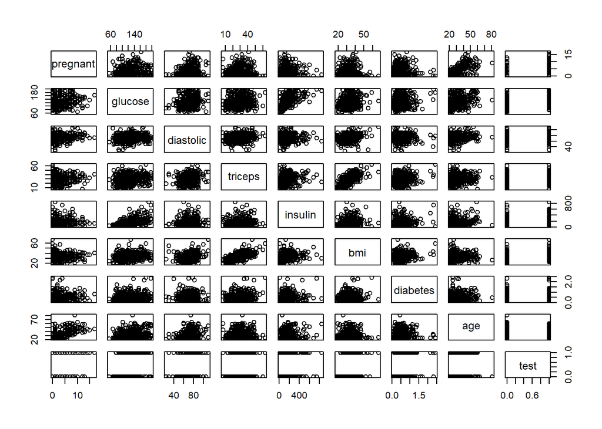

```r
pairs(pima1)
```

```r
vif(pima1)
```

```
##  pregnant   glucose diastolic   triceps   insulin       bmi  diabetes       age
##  1.912621  1.939119  1.231818  1.854913  1.557621  2.009136  1.079602  2.154163
##      test
##  1.528522
```

```r
# response = diabetes test result--test
# pred = pregnant ,glucose,diastolic,triceps  ,insulin  ,bmi, diabetes , age,
# total data obsrvtn = 768

set.seed(456)

#split the data into two parts 70-30 split
DataSplit<-createDataPartition(y = pima1$test, p = 0.7, list = FALSE)

#creating the train and test data set

p_tr <- pima1[DataSplit,]   #training data
p_tes <- pima1[-DataSplit,]  # test data


p_tr$test <- as.factor(p_tr$test)

library(tree)



# tree model

# training data

tree_diabetes <- tree(test ~ ., data = p_tr)

summary(tree_diabetes)
```

```
##
## Classification tree:
## tree(formula = test ~ ., data = p_tr)
## Number of terminal nodes:  21
## Residual mean deviance:  0.5629 = 143 / 254
## Misclassification error rate: 0.12 = 33 / 275
```

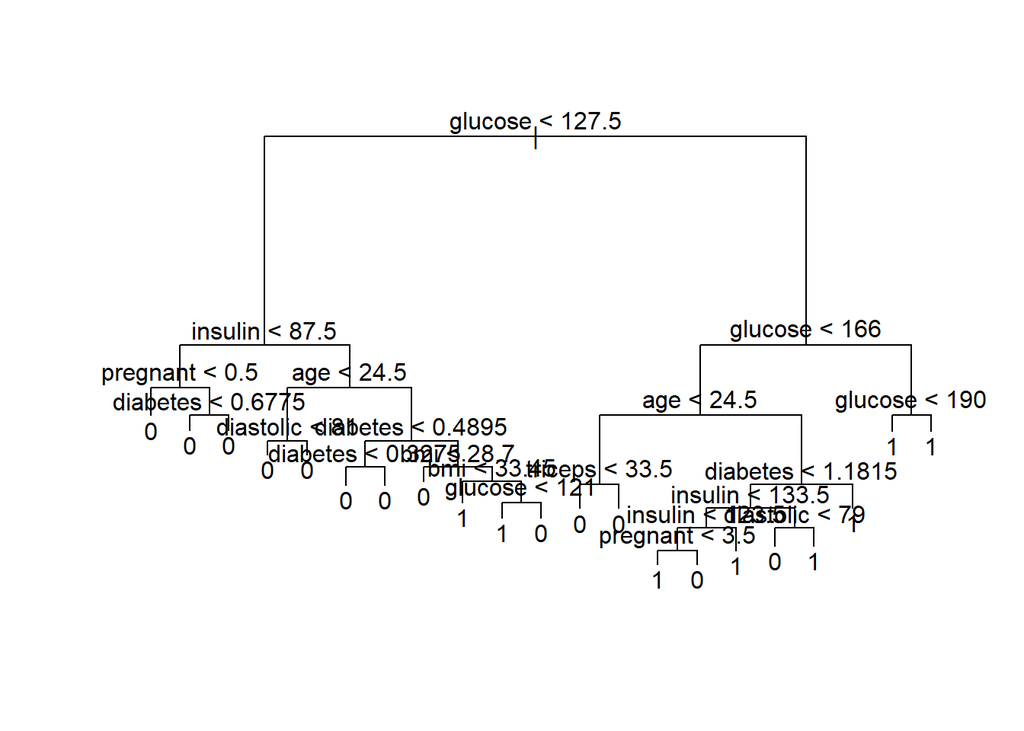

```r
plot(tree_diabetes)
text(tree_diabetes, pretty = 0)
```

```r
# Assessing if  cross validation and pruning will improve the model

cv_tree_diabetes  <- cv.tree(tree_diabetes, FUN = prune.misclass)


names(cv_tree_diabetes)
```

```
## [1] "size"   "dev"    "k"      "method"
```

```r
cv_tree_diabetes
```

```
## $size
## [1] 21 15 13  7  4  2  1
##
## $dev
## [1] 72 74 64 66 61 75 90
##
## $k
## [1] -Inf  0.0  1.0  1.5  3.0  9.0 18.0
##
## $method
## [1] "misclass"
##
## attr(,"class")
## [1] "prune"         "tree.sequence"
```

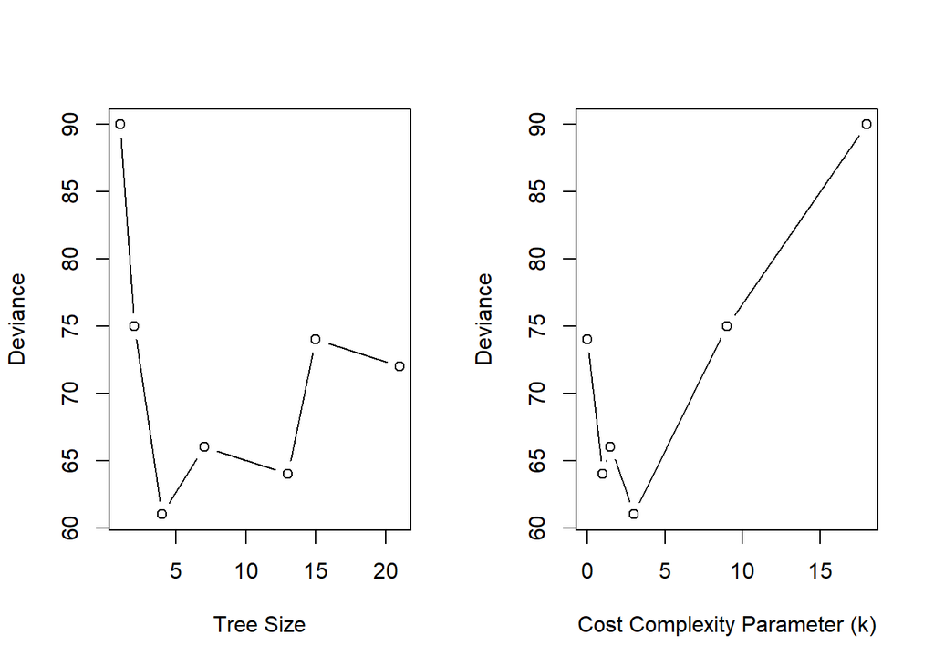

```r
par(mfrow = c(1, 2))
plot(cv_tree_diabetes$size, cv_tree_diabetes$dev, type = "b", xlab = "Tree Size", ylab = "Deviance")
plot(cv_tree_diabetes$k, cv_tree_diabetes$dev, type = "b", xlab = "Cost Complexity Parameter (k)", ylab = "Deviance")
```

```r
# checking the lowest deviance and the corresponding size to assess the best model.

# lowest deviance is 60 and size is 4

pruned_tree_diabetes <- prune.misclass(tree_diabetes, best = 4)

plot(pruned_tree_diabetes)
text(pruned_tree_diabetes, pretty = 0)

summary(pruned_tree_diabetes)
```

```
##
## Classification tree:
## snip.tree(tree = tree_diabetes, nodes = c(7L, 12L, 2L, 13L))
## Variables actually used in tree construction:
## [1] "glucose" "age"
## Number of terminal nodes:  4
## Residual mean deviance:  0.9221 = 249.9 / 271
## Misclassification error rate: 0.1927 = 53 / 275
```

```r
# Checking the performance of the pruned tree model on the test data set.


p_tes$test <- as.factor(p_tes$test)
tree.pred <- predict(pruned_tree_diabetes,p_tes, type = "class")

table(tree.pred, p_tes$test)
```

```
##
## tree.pred  0  1
##         0 68 14
##         1  8 27
```

```r
str(p_tes)
```

```
## 'data.frame':    117 obs. of  9 variables:
##  $ pregnant : int  1 5 3 3 4 5 8 7 0 2 ...
##  $ glucose  : int  89 166 158 88 111 88 176 187 105 110 ...
##  $ diastolic: int  66 72 76 58 72 66 90 68 64 74 ...
##  $ triceps  : int  23 19 36 11 47 21 34 39 41 29 ...
##  $ insulin  : int  94 175 245 54 207 23 300 304 142 125 ...
##  $ bmi      : num  28.1 25.8 31.6 24.8 37.1 24.4 33.7 37.7 41.5 32.4 ...
##  $ diabetes : num  0.167 0.587 0.851 0.267 1.39 0.342 0.467 0.254 0.173 0.698 ...
##  $ age      : int  21 51 28 22 56 30 58 41 22 27 ...
##  $ test     : Factor w/ 2 levels "0","1": 1 2 2 1 2 1 2 2 1 1 ...
##  - attr(*, "na.action")= 'omit' Named int [1:376] 1 2 3 6 8 10 11 12 13 16 ...
##   ..- attr(*, "names")= chr [1:376] "1" "2" "3" "6" ...
```

```r
p_tes
```

|  | pregnant | glucose | diastolic | triceps | insulin | bmi | diabetes | age | test |
| --- | --- | --- | --- | --- | --- | --- | --- | --- | --- |
| 4 | 1 | 89 | 66 | 23 | 94 | 28.1 | 0.167 | 21 | 0 |
| 15 | 5 | 166 | 72 | 19 | 175 | 25.8 | 0.587 | 51 | 1 |
| 32 | 3 | 158 | 76 | 36 | 245 | 31.6 | 0.851 | 28 | 1 |
| 33 | 3 | 88 | 58 | 11 | 54 | 24.8 | 0.267 | 22 | 0 |
| 40 | 4 | 111 | 72 | 47 | 207 | 37.1 | 1.390 | 56 | 1 |
| 53 | 5 | 88 | 66 | 21 | 23 | 24.4 | 0.342 | 30 | 0 |
| 54 | 8 | 176 | 90 | 34 | 300 | 33.7 | 0.467 | 58 | 1 |
| 57 | 7 | 187 | 68 | 39 | 304 | 37.7 | 0.254 | 41 | 1 |
| 60 | 0 | 105 | 64 | 41 | 142 | 41.5 | 0.173 | 22 | 0 |
| 86 | 2 | 110 | 74 | 29 | 125 | 32.4 | 0.698 | 27 | 0 |

[output cut: 107 more lines]

```r
library(gmodels)
CrossTable(p_tes$test, tree.pred,prop.chisq = FALSE, prop.c = FALSE, prop.r = FALSE, dnn = c('actual test', 'predicted test'))
```

```
##
##
##    Cell Contents
## |-------------------------|
## |                       N |
## |         N / Table Total |
## |-------------------------|
##
##
## Total Observations in Table:  117
##
##
##              | predicted test
##  actual test |         0 |         1 | Row Total |
## -------------|-----------|-----------|-----------|
##            0 |        68 |         8 |        76 |
##              |     0.581 |     0.068 |           |
## -------------|-----------|-----------|-----------|
##            1 |        14 |        27 |        41 |
##              |     0.120 |     0.231 |           |
## -------------|-----------|-----------|-----------|
## Column Total |        82 |        35 |       117 |
## -------------|-----------|-----------|-----------|
##
##
```

```r
library(caret)
confusion_matrix_t <- confusionMatrix(as.factor(tree.pred),as.factor(p_tes$test),mode="prec_recall", positive = "1")

confusion_matrix_t
```

```
## Confusion Matrix and Statistics
##
##           Reference
## Prediction  0  1
##          0 68 14
##          1  8 27
##
##                Accuracy : 0.812
##                  95% CI : (0.7293, 0.8782)
##     No Information Rate : 0.6496
##     P-Value [Acc > NIR] : 0.00008781
##
##                   Kappa : 0.5726
##
##  Mcnemar's Test P-Value : 0.2864
##
##               Precision : 0.7714
##                  Recall : 0.6585
##                      F1 : 0.7105
##              Prevalence : 0.3504
##          Detection Rate : 0.2308
##    Detection Prevalence : 0.2991
##       Balanced Accuracy : 0.7766
##
##        'Positive' Class : 1
##
```

```r
# accuracy = tp +tn/ 117 *100
a = (68+27)/117
a*100
```

```
## [1] 81.19658
```

[figure not shown]

Evaluation of the model on test data:

Accuracy: This model tree has an accuracy of 81.2 percent which means it is a good model. Precision: The precision of 77.14 perecnt is also good as it can correctly predict 77 percent positive cases. Recall : Of the all positive cases it did identify 65.85 percent correctly or true positives . This is moderate performance as it identified only 27 true positives and the 8 were false positives.

F1 : precision/recall = It has an F1 score of 71 percent which is good.

Overall the model is good i terms of accuracy with 81.2 percent accuracy but has limited ability in terms of predicting true positives. So we may need to improve overall precision by boosting.

# end

b-) Use Bagging method on the train data set and evaluate the performance on the test data set. (5 pts)

Step 1: use p_tr for bagging method.

Step 2: use ipred library for bagging model creation.

Step 3: Analyse performance on test data by means of predict fn and confusion matrix - accuracy, precision , recall and f1 score with true and false positives .

```r
# p_tr

p_tr$test <- as.factor(p_tr$test)
p_tes$test <- as.factor(p_tes$test)

library(ipred)

set.seed(456)

pima_bag <- bagging(test ~ ., data = p_tr, nbagg = 25)
summary(pima_bag)
```

```
##
## Bagging classification trees with 25 bootstrap replications
##
## Call: bagging.data.frame(formula = test ~ ., data = p_tr, nbagg = 25)
```

[output not shown]

[output cut: 2674 more lines]

[output not shown]

```r
pima_pred <- predict(pima_bag, p_tes)

table(pima_pred, p_tes$test)
```

```
##
## pima_pred  0  1
##         0 68 15
##         1  8 26
```

```r
library(gmodels)
CrossTable(p_tes$test, pima_pred,prop.chisq = FALSE, prop.c = FALSE, prop.r = FALSE, dnn = c('actual test', 'predicted test'))
```

```
##
##
##    Cell Contents
## |-------------------------|
## |                       N |
## |         N / Table Total |
## |-------------------------|
##
##
## Total Observations in Table:  117
##
##
##              | predicted test
##  actual test |         0 |         1 | Row Total |
## -------------|-----------|-----------|-----------|
##            0 |        68 |         8 |        76 |
##              |     0.581 |     0.068 |           |
## -------------|-----------|-----------|-----------|
##            1 |        15 |        26 |        41 |
##              |     0.128 |     0.222 |           |
## -------------|-----------|-----------|-----------|
## Column Total |        83 |        34 |       117 |
## -------------|-----------|-----------|-----------|
##
##
```

```r
# Create confusion matrix

library(caret)

confusion_matrix_p <- confusionMatrix(as.factor(pima_pred),as.factor(p_tes$test),mode="prec_recall", positive = "1")

confusion_matrix_p
```

```
## Confusion Matrix and Statistics
##
##           Reference
## Prediction  0  1
##          0 68 15
##          1  8 26
##
##                Accuracy : 0.8034
##                  95% CI : (0.7198, 0.8711)
##     No Information Rate : 0.6496
##     P-Value [Acc > NIR] : 0.0002033
##
##                   Kappa : 0.5505
##
##  Mcnemar's Test P-Value : 0.2109029
##
##               Precision : 0.7647
##                  Recall : 0.6341
##                      F1 : 0.6933
##              Prevalence : 0.3504
##          Detection Rate : 0.2222
##    Detection Prevalence : 0.2906
##       Balanced Accuracy : 0.7644
##
##        'Positive' Class : 1
##
```

CONCLUSION:

1. accuracy - Overall accuracy is 80.34 percent which is good
2. precision - total positives is 76.47 percent which is good however only 63.4 percent are true positives. 3.recall - it predicts 63.41 percent of true positives which is moderate.
3. F1 score - 69.33 - the F1 score is also 69 percent which is moderate .

Overall, the performance is moderate in terms of accuracy with 26 true positives and has 8 false positives.However the preciison is more than recall and false positive is less compared to the true positives.

# end

c-) Use Boosting method on the train data set and evaluate the performance on the test data set. (5 pts)

Step 1: change the response into factors .

Step 2: use library C50 for boosting with 10 trials .

Step3: analyse the model on train data

Step 4: evaluate the performance on tests data using cross table and confusion matrix

Step 5:

```r
# boosting

library(C50)

p_tr$test <- as.factor(p_tr$test)
p_tes$test <- as.factor(p_tes$test)


# Train the boosting model on the training data with 10 trials
pima_boost10 <- C5.0(test ~ ., data = p_tr, trials = 10)

# Summarize the boosting model
summary(pima_boost10)
```

```
##
## Call:
## C5.0.formula(formula = test ~ ., data = p_tr, trials = 10)
##
##
## C5.0 [Release 2.07 GPL Edition]      Wed Nov 13 15:45:49 2024
## -------------------------------
##
## Class specified by attribute `outcome'
##
## Read 275 cases (9 attributes) from undefined.data
##
## -----  Trial 0:  -----
##
## Decision tree:
##
## glucose > 127:
## :...glucose > 165: 1 (30/3)
## :   glucose <= 165:
## :   :...age <= 24: 0 (22/2)
## :       age > 24: 1 (60/24)
## glucose <= 127:
## :...age <= 27: 0 (103/8)
##     age > 27:
##     :...insulin <= 87: 0 (22)
##         insulin > 87:
##         :...diabetes <= 0.497: 0 (17/3)
##             diabetes > 0.497:
##             :...bmi <= 25.9: 0 (3)
##                 bmi > 25.9:
##                 :...triceps <= 41: 1 (13/1)
##                     triceps > 41: 0 (5/1)
##
## -----  Trial 1:  -----
##
## Decision tree:
##
## glucose > 165: 1 (27.9/6.4)
## glucose <= 165:
## :...bmi <= 30.2: 0 (88.9/10.9)
```

[output cut: 115 more lines]

```
##
##
##  Attribute usage:
##
##  100.00% glucose
##  100.00% bmi
##  100.00% age
##   85.82% insulin
##   84.73% pregnant
##   65.09% diabetes
##   54.55% triceps
##   23.64% diastolic
##
##
## Time: 0.0 secs
```

```r
# predict on test

pima_boost_pred10 <- predict(pima_boost10, p_tes)

# cross table

library(gmodels)

CrossTable(p_tes$test, pima_boost_pred10,prop.chisq = FALSE, prop.c = FALSE, prop.r = FALSE,
dnn = c('actual test', 'predicted test'))
```

```
##
##
##    Cell Contents
## |-------------------------|
## |                       N |
## |         N / Table Total |
## |-------------------------|
##
##
## Total Observations in Table:  117
##
##
##              | predicted test
##  actual test |         0 |         1 | Row Total |
## -------------|-----------|-----------|-----------|
##            0 |        70 |         6 |        76 |
##              |     0.598 |     0.051 |           |
## -------------|-----------|-----------|-----------|
##            1 |        12 |        29 |        41 |
##              |     0.103 |     0.248 |           |
## -------------|-----------|-----------|-----------|
## Column Total |        82 |        35 |       117 |
## -------------|-----------|-----------|-----------|
##
##
```

```r
confusion_matrix_boost <- confusionMatrix(as.factor(pima_boost_pred10),as.factor(p_tes$test), mode = "prec_recall", positive = "1")

confusion_matrix_boost
```

```
## Confusion Matrix and Statistics
##
##           Reference
## Prediction  0  1
##          0 70 12
##          1  6 29
##
##                Accuracy : 0.8462
##                  95% CI : (0.7678, 0.9062)
##     No Information Rate : 0.6496
##     P-Value [Acc > NIR] : 0.000001759
##
##                   Kappa : 0.6503
##
##  Mcnemar's Test P-Value : 0.2386
##
##               Precision : 0.8286
##                  Recall : 0.7073
##                      F1 : 0.7632
##              Prevalence : 0.3504
##          Detection Rate : 0.2479
##    Detection Prevalence : 0.2991
##       Balanced Accuracy : 0.8142
##
##        'Positive' Class : 1
##
```

CONCLUSION:

Overall, the performance is good in terms of accuracy of 84 percent with 29 true positives and only 6 false positives and true positives being more than false positives. The precision is more than recall which is also good.

# end

d-) Use Random Forest method on the train data set and evaluate the performance on the test data set. (5 pts) tep 1:Set the seed and RNG version

Step 2:use the random Forest fn to use the random forest method.

Step3: use predict to cal performance on test data

Step 4: use confusion matrix to compare.

```r
# random forest

library(randomForest)
set.seed(456)


p_tr$test <- as.factor(p_tr$test)

p_tes$test <- as.factor(p_tes$test)

rf <- randomForest(test ~ ., data = p_tr)
rf
```

```
##
## Call:
##  randomForest(formula = test ~ ., data = p_tr)
##                Type of random forest: classification
##                      Number of trees: 500
## No. of variables tried at each split: 2
##
##         OOB estimate of  error rate: 23.27%
## Confusion matrix:
##     0  1 class.error
## 0 160 26   0.1397849
## 1  38 51   0.4269663
```

```r
# predict on test data

pima_rf_pred <- predict(rf, p_tes)



confusion_matrix_rf <- confusionMatrix(as.factor(pima_rf_pred), as.factor(p_tes$test), mode = "prec_recall", positive = "1")
confusion_matrix_rf
```

```
## Confusion Matrix and Statistics
##
##           Reference
## Prediction  0  1
##          0 70 16
##          1  6 25
##
##                Accuracy : 0.812
##                  95% CI : (0.7293, 0.8782)
##     No Information Rate : 0.6496
##     P-Value [Acc > NIR] : 0.00008781
##
##                   Kappa : 0.5624
##
##  Mcnemar's Test P-Value : 0.05501
##
##               Precision : 0.8065
##                  Recall : 0.6098
##                      F1 : 0.6944
##              Prevalence : 0.3504
##          Detection Rate : 0.2137
##    Detection Prevalence : 0.2650
##       Balanced Accuracy : 0.7654
##
##        'Positive' Class : 1
##
```

CONCLUSION :

1. accuracy - Overall accuracy is 81.2 percent which is good
2. precision - total positives is 80.65 percent which is good however only 60.9 percent are true positives. 3.recall - it predicts 60.98 percent of true positives which is moderate.
3. F1 score - 69.44 - the F1 score is also 69 percent which is moderate .

Overall, the performance is moderate in terms of accuracy with 25 true positives and has 6 false positives.However even though precision is more than recall and false positive is less compared to the true positives, only 60 percent is true positive out of 80 percent. The performance in terms of predicting true positives is not that good..

# end

e-) Check the model performances of each on the test data set, which model would you choose? (5 Points)

Step 1: create a dataframe to include main analysis measures - accuracy, f1, recall and precision

Step 2: use rbind to put them in a dataframe

Step3: Analyse and compare the models.

```r
# analysis on tree, bagging, boosting and random forest

# best model of all -
# using cross validation  to anlayse performance


#tree

tree_accuracy <- confusion_matrix_t$overall['Accuracy']
tree_precision <- confusion_matrix_t$byClass['Precision']
tree_recall <- confusion_matrix_t$byClass['Recall']
tree_f1 <- confusion_matrix_t$byClass['F1']

tree_metrics <- c(Accuracy = tree_accuracy,Precision = tree_precision, Recall= tree_recall ,F1 = tree_f1)



bagging_accuracy <- confusion_matrix_p$overall['Accuracy']
bagging_precision <- confusion_matrix_p$byClass['Precision']
bagging_recall <- confusion_matrix_p$byClass['Recall']
bagging_f1 <- confusion_matrix_p$byClass['F1']

bagging_metrics <- c(Accuracy = bagging_accuracy,Precision = bagging_precision, Recall= bagging_recall ,F1 = bagging_f1)



boosting_accuracy <- confusion_matrix_boost$overall['Accuracy']
boosting_precision <- confusion_matrix_boost$byClass['Precision']
boosting_recall <- confusion_matrix_boost$byClass['Recall']
boosting_f1 <- confusion_matrix_boost$byClass['F1']

boosting_metrics <- c(Accuracy = boosting_accuracy,Precision = boosting_precision,Recall = boosting_recall,F1 = boosting_f1)


rf_accuracy <- confusion_matrix_rf$overall['Accuracy']
rf_precision <- confusion_matrix_rf$byClass['Precision']
rf_recall <- confusion_matrix_rf$byClass['Recall']
rf_f1 <- confusion_matrix_rf$byClass['F1']

rf_metrics <- c( Accuracy = rf_accuracy,Precision = rf_precision,Recall = rf_recall,
F1 = rf_f1)

model_comparison <- rbind(tree_metrics = tree_metrics, Bagging = bagging_metrics,Boosting = boosting_metrics, Random_Forest = rf_metrics)

model_comparison
```

```
##               Accuracy.Accuracy Precision.Precision Recall.Recall     F1.F1
## tree_metrics          0.8119658           0.7714286     0.6585366 0.7105263
## Bagging               0.8034188           0.7647059     0.6341463 0.6933333
## Boosting              0.8461538           0.8285714     0.7073171 0.7631579
## Random_Forest         0.8119658           0.8064516     0.6097561 0.6944444
```

CONCLUSION: 1. accuracy - Boosting model has the best performance of 84 percent compared to others and bagging has the least. 2. Precision- Boosting again has a good precision percentage of 82 perecnt better than the other models. 3. recall - Boosting has the highest recall value and is hence good at predicting true positives compared to others. The tree model is the next better model and Random forest model is the worst at predicting true positives or recall. 4. F1 score - boosting has the best F1 score of 76 compared to other models.

Boosting model is based on the trial and error and boosts or improving the performance based on the errors found in the earlier trial. This finding makes sense.

Overall, i would choose the boosting model among these based on the performances on the test data with good accuracy and precision and recall.

# end

## Problem 3

Refer to the Prostate cancer data set. Serum prostate-specific antigen (PSA) was determined in 97 men with advanced prostate cancer. PSA is a well-established screening test for prostate cancer and the oncologists wanted to examine the correlation between level of PSA and a number of clinical measures for men who were about to undergo radical prostatectomy. The measures are cancer volume, prostate weight, patient age, the amount of benign prostatic hyperplasia, seminal vesicle invasion, capsular penetration, and Gleason score. (50 pts)

Select a random sample of 65 observations to use as the train data set (Please use set.seed(567)) and reamining observations as the test data set.

Use the train data set to answer the following questions.

a-) Develop a best subset model for predicting PSA. Justify your choice of model. Assess your model’s ability to predict and discuss its usefulness to the oncologists.(5 pts)

Step 1: Load and use nrow to split the data into needed training and test data.

Step 2: Generate Best subset model by using subset regression

Step3: Analyse the performance using predict fn. # Best subset model will be with 1. High adj R square, 2. low Cp 3. Low AIC 4. low SBIC and 5. Low SBC

```r
c_data <- read.csv("C:\\DATA_MODELING\\Assignments\\asignment09\\CSCI E-106 Assignment 9\\Prostate Cancer.csv")


str(c_data)
```

```
## 'data.frame':    97 obs. of  8 variables:
##  $ PSA.level                   : num  0.651 0.852 0.852 0.852 1.448 ...
##  $ Cancer.volume               : num  0.56 0.372 0.601 0.301 2.117 ...
##  $ Weight                      : num  16 27.7 14.7 26.6 30.9 ...
##  $ Age                         : int  50 58 74 58 62 50 64 58 47 63 ...
##  $ Benign.prostatic.hyperplasia: num  0 0 0 0 0 ...
##  $ Seminal.vesicle.invasion    : int  0 0 0 0 0 0 0 0 0 0 ...
##  $ Capsular.penetration        : num  0 0 0 0 0 0 0 0 0 0 ...
##  $ Gleason.score               : int  6 7 7 6 6 6 6 6 7 6 ...
```

```r
names(c_data)
```

```
## [1] "PSA.level"                    "Cancer.volume"
## [3] "Weight"                       "Age"
## [5] "Benign.prostatic.hyperplasia" "Seminal.vesicle.invasion"
## [7] "Capsular.penetration"         "Gleason.score"
```

```r
head(c_data)
```

|  | PSA.level | Cancer.volume | Weight | Age | Benign.prostatic.hyperplasia | Seminal.vesicle.invasion | Capsular.penetration | Gleason.score |
| --- | --- | --- | --- | --- | --- | --- | --- | --- |
| 1 | 0.651 | 0.5599 | 15.959 | 50 | 0 | 0 | 0 | 6 |
| 2 | 0.852 | 0.3716 | 27.660 | 58 | 0 | 0 | 0 | 7 |
| 3 | 0.852 | 0.6005 | 14.732 | 74 | 0 | 0 | 0 | 7 |
| 4 | 0.852 | 0.3012 | 26.576 | 58 | 0 | 0 | 0 | 6 |
| 5 | 1.448 | 2.1170 | 30.877 | 62 | 0 | 0 | 0 | 6 |
| 6 | 2.160 | 0.3499 | 25.280 | 50 | 0 | 0 | 0 | 6 |

```r
# total - 97
# response var -PSA.
# predictor var - cancer volume, prostate weight, patient age, the amount of benign prostatic hyperplasia, seminal vesicle invasion, capsular penetration, and Gleason score

set.seed(567)

cancer.train_sample <- sample(1:nrow(c_data), 65)
cancer.train<- c_data[cancer.train_sample, ]

cancer.test  <- c_data[-cancer.train_sample, ]


str(cancer.train)
```

```
## 'data.frame':    65 obs. of  8 variables:
##  $ PSA.level                   : num  3.56 6.17 19.3 20.29 39.65 ...
##  $ Cancer.volume               : num  5.003 0.67 0.638 6.424 7.538 ...
##  $ Weight                      : num  20.5 47.9 82.3 36.2 41.7 ...
##  $ Age                         : int  63 67 69 60 58 61 59 68 70 77 ...
##  $ Benign.prostatic.hyperplasia: num  0 6.17 0 0 5.16 ...
##  $ Seminal.vesicle.invasion    : int  0 0 0 1 0 0 0 1 0 1 ...
##  $ Capsular.penetration        : num  0.549 0 0 3.743 0 ...
##  $ Gleason.score               : int  7 7 6 7 6 7 6 6 7 7 ...
```

```r
str(cancer.test)
```

```
## 'data.frame':    32 obs. of  8 variables:
##  $ PSA.level                   : num  0.852 1.448 2.16 3.561 4.759 ...
##  $ Cancer.volume               : num  0.601 2.117 0.35 1.284 0.571 ...
##  $ Weight                      : num  14.7 30.9 25.3 36.6 26.3 ...
##  $ Age                         : int  74 62 50 65 41 60 63 68 65 65 ...
##  $ Benign.prostatic.hyperplasia: num  0 0 0 0 0 ...
##  $ Seminal.vesicle.invasion    : int  0 0 0 0 0 0 0 0 0 0 ...
##  $ Capsular.penetration        : num  0 0 0 0 0 ...
##  $ Gleason.score               : int  7 6 6 6 6 7 7 6 6 6 ...
```

```r
cancer_model <-lm(PSA.level~.,data = cancer.train)
summary(cancer_model)
```

```
##
## Call:
## lm(formula = PSA.level ~ ., data = cancer.train)
##
## Residuals:
##     Min      1Q  Median      3Q     Max
## -58.959 -10.534   0.546   7.886 136.999
##
## Coefficients:
##                              Estimate Std. Error t value Pr(>|t|)
## (Intercept)                   36.0596    48.0216   0.751  0.45580
## Cancer.volume                  1.2769     0.6998   1.825  0.07327 .
## Weight                         0.4520     0.2845   1.589  0.11765
## Age                           -1.2624     0.5821  -2.169  0.03429 *
## Benign.prostatic.hyperplasia  -0.5805     1.6757  -0.346  0.73029
## Seminal.vesicle.invasion      -6.8214    13.9254  -0.490  0.62612
## Capsular.penetration           4.7785     1.5119   3.161  0.00252 **
## Gleason.score                  4.2182     5.7792   0.730  0.46844
## ---
## Signif. codes:  0 '***' 0.001 '**' 0.01 '*' 0.05 '.' 0.1 ' ' 1
##
## Residual standard error: 28.31 on 57 degrees of freedom
## Multiple R-squared:  0.5555, Adjusted R-squared:  0.5009
## F-statistic: 10.17 on 7 and 57 DF,  p-value: 0.00000003443
```

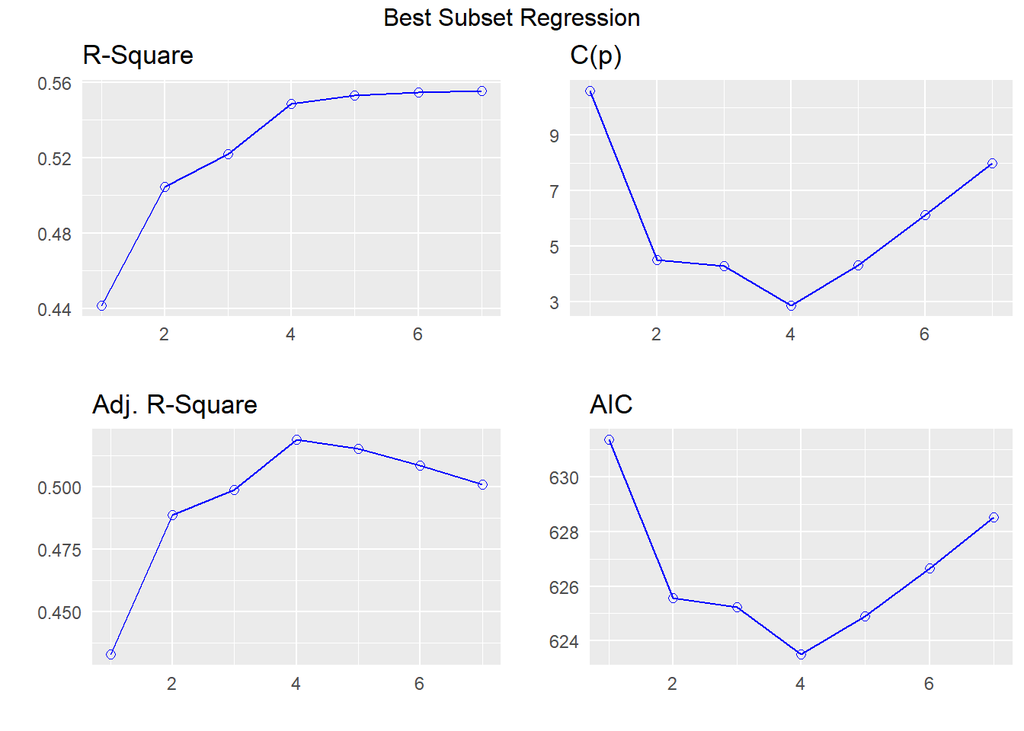

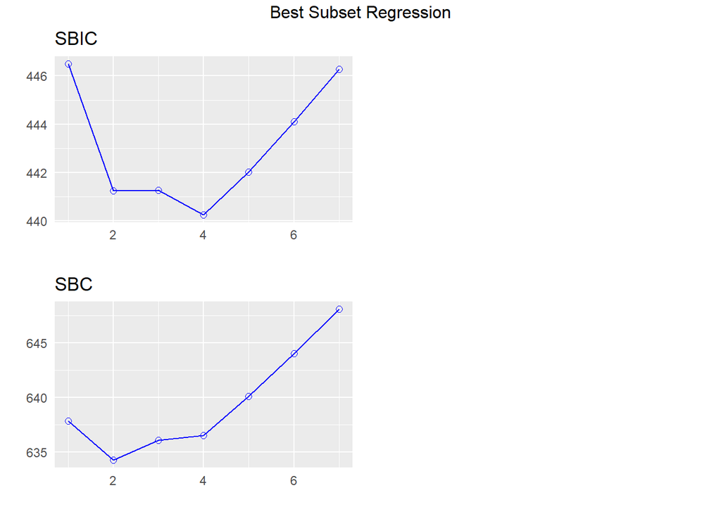

```r
# adj R sq = 0.5009 and p values of all variables except age and capsular penetration are insignificant( >0.05) # rmse = 28.31

#  Best subset

k1<-ols_step_best_subset(cancer_model)
plot(k1)
```

```r
k1
```

```
##                                                     Best Subsets Regression
## --------------------------------------------------------------------------------------------------------------------------------
## Model Index    Predictors
## --------------------------------------------------------------------------------------------------------------------------------
##      1         Capsular.penetration
##      2         Cancer.volume Capsular.penetration
##      3         Cancer.volume Age Capsular.penetration
##      4         Cancer.volume Weight Age Capsular.penetration
##      5         Cancer.volume Weight Age Capsular.penetration Gleason.score
##      6         Cancer.volume Weight Age Seminal.vesicle.invasion Capsular.penetration Gleason.score
##      7         Cancer.volume Weight Age Benign.prostatic.hyperplasia Seminal.vesicle.invasion Capsular.penetration Gleason.score
## --------------------------------------------------------------------------------------------------------------------------------
##
##                                                       Subsets Regression Summary
## ---------------------------------------------------------------------------------------------------------------------------------------
##                        Adj.        Pred
## Model    R-Square    R-Square    R-Square     C(p)        AIC         SBIC        SBC          MSEP         FPE         HSP       APC
## ---------------------------------------------------------------------------------------------------------------------------------------
##   1        0.4416      0.4327      0.2351    10.6000    631.3454    446.4976    637.8685    59188.1102    938.5900    14.6867    0.5939
##   2        0.5046      0.4886      0.2953     4.5179    625.5601    441.2370    634.2577    53367.8467    858.7016    13.4560    0.5433
##   3        0.5220      0.4985      0.2891     4.2893    625.2385    441.2535    636.1104    52353.5788    854.5400    13.4167    0.5407
##   4        0.5487      0.5186      0.3087     2.8644    623.5008    440.2416    636.5471    50265.7867    832.1216    13.0963    0.5265
##   5        0.5529      0.5150      0.2979     4.3294    624.8970    442.0048    640.1178    50659.6704    850.3784    13.4227    0.5381
##   6        0.5545      0.5084      0.2452     6.1200    626.6593    444.0906    644.0544    51360.2050    874.0205    13.8429    0.5530
##   7        0.5555      0.5009      0.2382     8.0000    628.5225    446.2667    648.0920    52167.5082    899.8117    14.3072    0.5693
## ---------------------------------------------------------------------------------------------------------------------------------------
## AIC: Akaike Information Criteria
##  SBIC: Sawa's Bayesian Information Criteria
##  SBC: Schwarz Bayesian Criteria
##  MSEP: Estimated error of prediction, assuming multivariate normality
##  FPE: Final Prediction Error
##  HSP: Hocking's Sp
##  APC: Amemiya Prediction Criteria
```

```r
#  4-  Cancer.volume Weight Age Capsular.penetration

# according to the plots , model 4  is the best subset with highest R squared and lowest cp and lowest AIC.

# model 4
cancer_model4 <-lm(PSA.level~ Cancer.volume + Weight + Age + Capsular.penetration,data = cancer.train)
summary(cancer_model4)
```

```
##
## Call:
## lm(formula = PSA.level ~ Cancer.volume + Weight + Age + Capsular.penetration,
##     data = cancer.train)
##
## Residuals:
##     Min      1Q  Median      3Q     Max
## -58.871  -8.535   0.807   8.136 139.070
##
## Coefficients:
##                      Estimate Std. Error t value Pr(>|t|)
## (Intercept)           63.7453    33.1920   1.921 0.059551 .
## Cancer.volume          1.4096     0.6078   2.319 0.023813 *
## Weight                 0.3858     0.2047   1.884 0.064346 .
## Age                   -1.2444     0.5633  -2.209 0.030994 *
## Capsular.penetration   4.4643     1.2669   3.524 0.000821 ***
## ---
## Signif. codes:  0 '***' 0.001 '**' 0.01 '*' 0.05 '.' 0.1 ' ' 1
##
## Residual standard error: 27.8 on 60 degrees of freedom
## Multiple R-squared:  0.5487, Adjusted R-squared:  0.5186
## F-statistic: 18.24 on 4 and 60 DF,  p-value: 0.0000000007512
```

```r
PredictedTrain<-predict(cancer_model4,cancer.train)
ModelTrain<-data.frame(obs = cancer.train$PSA.level, pred=PredictedTrain)
Model_Train=defaultSummary(ModelTrain)

PredictedTest<-predict(cancer_model4,cancer.test)
ModelTest<-data.frame(obs = cancer.test$PSA.level, pred=PredictedTest)
Model_Test=defaultSummary(ModelTest)



g = rbind(Model_Train,Model_Test)
g
```

```
##                 RMSE   Rsquared      MAE
## Model_Train 26.70669 0.54870875 15.66803
## Model_Test  49.32220 0.03498288 28.63858
```

CONCLUSION: 1.R square- 54 and RMSE - 27.8 2.Cp - 2.8644 3.AIC - 623.5008 4. p value – all except weight is significant.

The R squared is just above average in the training data at 54 percent. However When using the model on test data , the model has low R squared of 3 percent. This indicates that this model can ’t be used on new test data. This can also be because the test data has only 32 observations. This model in it present state is not very helpful for the oncologists as it can’t predict PSA levels based on the weight and other variables.

# end

b-) Develop a regression tree for predicting PSA. Justify your choice of number of regions (tree size), and interpret your regression tree. (10 pts)

Step 1: install the required pkgs.

Step 2: Set seed and use tree fn to create tree model.

Step3: do the cross validation and find the size with min deviance

Step 4: prune the tree using the best size - lowest deviance and simplicity

Step 5:plot and analyse .

```r
install.packages("tree")
library(tree)

set.seed(567)
tree_psa <- tree(PSA.level ~ ., data = cancer.train)
summary(tree_psa)
```

```
##
## Regression tree:
## tree(formula = PSA.level ~ ., data = cancer.train)
## Variables actually used in tree construction:
## [1] "Cancer.volume"
## Number of terminal nodes:  3
## Residual mean deviance:  924.3 = 57310 / 62
## Distribution of residuals:
##    Min. 1st Qu.  Median    Mean 3rd Qu.    Max.
## -76.570  -6.071  -2.181   0.000   8.050 173.600
```

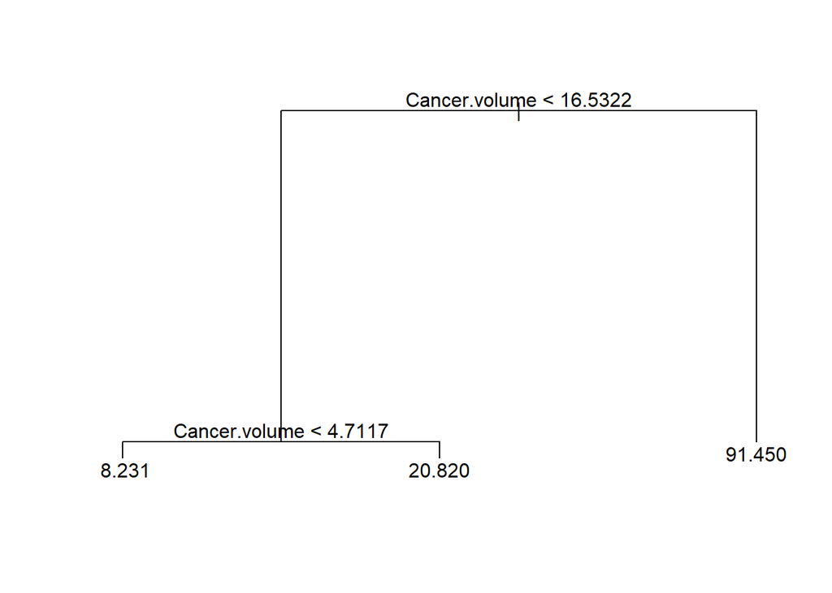

```r
plot(tree_psa)
text(tree_psa, pretty = 0)
```

```r
# Assessing if  cross validation and pruning will improve the model

cv_tree_cancer  <- cv.tree(tree_psa, FUN = prune.tree)

names(cv_tree_cancer)
```

```
## [1] "size"   "dev"    "k"      "method"
```

```r
cv_tree_cancer
```

```
## $size
## [1] 3 2 1
##
## $dev
## [1]  69345.33  70231.14 112868.66
##
## $k
## [1]      -Inf  2101.545 43318.697
##
## $method
## [1] "deviance"
##
## attr(,"class")
## [1] "prune"         "tree.sequence"
```

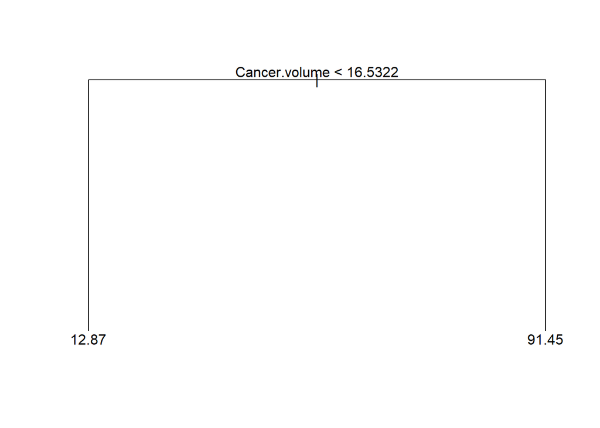

```r
# checking the lowest deviance and the corresponding size to assess the best model.

# even though size = 3 has the lowest deviance , size= 2 has also similar deviance and also has less predictors. This would be a better and simpler tree.


pruned_tree_cancer <- prune.tree(tree_psa, best = 2)

plot(pruned_tree_cancer)
text(pruned_tree_cancer, pretty = 0)
```

```r
summary(tree_psa)
```

```
##
## Regression tree:
## tree(formula = PSA.level ~ ., data = cancer.train)
## Variables actually used in tree construction:
## [1] "Cancer.volume"
## Number of terminal nodes:  3
## Residual mean deviance:  924.3 = 57310 / 62
## Distribution of residuals:
##    Min. 1st Qu.  Median    Mean 3rd Qu.    Max.
## -76.570  -6.071  -2.181   0.000   8.050 173.600
```

```r
summary(pruned_tree_cancer)
```

```
##
## Regression tree:
## snip.tree(tree = tree_psa, nodes = 2L)
## Variables actually used in tree construction:
## [1] "Cancer.volume"
## Number of terminal nodes:  2
## Residual mean deviance:  943 = 59410 / 63
## Distribution of residuals:
##    Min. 1st Qu.  Median    Mean 3rd Qu.    Max.
## -76.570  -8.605  -2.894   0.000   4.946 173.600
```

CONCLUSION: The original tree has 3 terminal nodes. After doing cross validation , the tree size with The deviance is lowest when size of the tree is 3 which is the same node size of the original tree without pruning.

Hence the tree with size = 2 is a better tree.

Interpretation of the regression tree :

1.Nodes -2 2. most important predictor –> Cancer.volume 3.Residual mean deviance: 943 = 59410 / 63

This is a simple tree with one split into 2 nodes with cancer volume the important predictor

# end

c-) Develop a lasso regression model to predict PSA and interpret your model. (10 pts)

Step 1: find the best lambda

Step 2: use the best lambda to find the lasso model

Step3: Analyse the model

```r
# loading the pkgs

install.packages("glmnet")
```

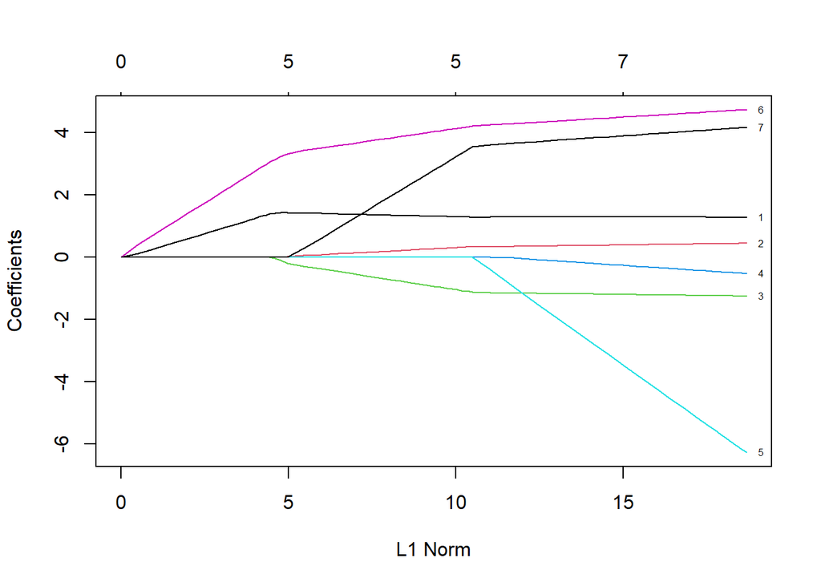

```r
library(glmnet)

#need to define X and Y matrix for glmnet

x <- model.matrix(PSA.level ~ ., data = cancer.train)[, -c(1)]  # Remove the intercept
y <- cancer.train$PSA.level

LassoMod <- glmnet(x, y, alpha=1, nlambda=100,lambda.min.ratio=0.0001)
plot(LassoMod,xvar="norm",label=TRUE)
```

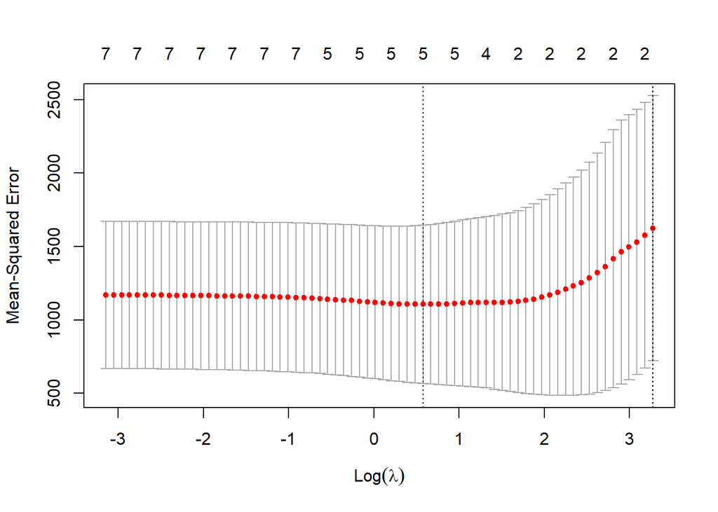

```r
CvLassoMod <- cv.glmnet(x, y, alpha=1, nlambda=100,lambda.min.ratio=0.0001)
plot(CvLassoMod)
```

```r
best.lambda.lasso <- CvLassoMod$lambda.min
best.lambda.lasso
```

```
## [1] 1.779019
```

```r
coef(CvLassoMod, s = "lambda.min")
```

```
## 8 x 1 sparse Matrix of class "dgCMatrix"
##                                      s1
## (Intercept)                  28.0685168
## Cancer.volume                 1.3382112
## Weight                        0.2149780
## Age                          -0.7732122
## Benign.prostatic.hyperplasia  .
## Seminal.vesicle.invasion      .
## Capsular.penetration          3.8737556
## Gleason.score                 2.1576018
```

```r
# the lasso regression model is : Y = beta0 + beta1*Cancer.volume + beta2*Weight + beta3*Age   + beat4 *Capsular.penetration + beta5*Gleason.score

# it has 5  predictor variables
```

# The lasso model is Y = beta0 + beta1*Cancer.volume + beta2*Weight + beta3*Age + beat4* Capsular.penetration + beta5*Gleason.score with 5 variables

The lasso model has kept 5 predictors.

# end

Use the test data set to answer the following questions.

d-) Compare the performance of your regression tree model with that of the best regression model. Which model is more easily interpreted and why? (10 pts)

Step 1: get the predicted values on the test

Step 2: compare the default summary

Step3: Get the predicted values on the tree model

Step 4:Compare both models based on r squared , RMSE and MSE

```r
# test data
# regression tree with best subset regression model
# Regression tree



cancer_pred_tes <- predict(pruned_tree_cancer,cancer.test)

ModelTest_t <- data.frame(obs = cancer.test$PSA.level, pred = cancer_pred_tes)

Model_Test_tree <- defaultSummary(ModelTest_t)
Model_Test_tree
```

```
##       RMSE   Rsquared        MAE
## 31.5984011  0.4773636 16.8173746
```

```r
# best regression model- cancer_model4

PredictedTest<-predict(cancer_model4,cancer.test)
ModelTest_R<-data.frame(obs = cancer.test$PSA.level, pred=PredictedTest)
Model_Test_reg=defaultSummary(ModelTest_R)



h = data.frame(rbind(Model_Test_tree,Model_Test_reg))
h
```

|  | RMSE | Rsquared | MAE |
| --- | --- | --- | --- |
| Model_Test_tree | 31.5984 | 0.47736357 | 16.81737 |
| Model_Test_reg | 49.3222 | 0.03498288 | 28.63858 |

CONCLUSION: Based on performance on test data, the tree model has a good R squared in the test data compared to the best subset model. The RMSE and MAE values are also less in the tree model . The tree model is easy to be interpreted with only one split and one predictor - cancer. volume but the best subset model has 4 predictors which is a bit more complicated and difficult to explain. hence the tree model is the better model in terms of simplicity and R squared, Rmse and MAE .

# end

e-) Compare the performance of your lasso regression model with that of the best regression model and tree model. (10 pts)

Step 1: get the predicted values based on the lasso model

Step 2: Analyse the performance on the test data.

Step3: compare the performancer with the best subset model and tree model.

```r
# test data

#  lasso comparison with best regression model and tree



x_test <- model.matrix(PSA.level ~ ., data = cancer.test)[, -1]
y_test <- cancer.test$PSA.level

y_hat.lasso <- predict(CvLassoMod, s = best.lambda.lasso, newx = x_test)

## Lasso Regression Model

Predicted<-c(y_hat.lasso)
ModelTest.lasso<-data.frame(obs = cancer.test$PSA.level, pred=Predicted)
lasso<-defaultSummary(ModelTest.lasso)


residuals_lasso <- ModelTest.lasso$obs - ModelTest.lasso$pred
squared_residuals_lasso <- residuals_lasso^2
SSE_lasso <- sum(squared_residuals_lasso)

SSE_lasso
```

```
## [1] 55785.88
```

```r
#RMSE

RMSE_lasso <- lasso['RMSE']


MSE_lasso <- RMSE_lasso^2



# tree model



d =data.frame(rbind(lasso,Model_Test_tree,Model_Test_reg))
d
```

|  | RMSE | Rsquared | MAE |
| --- | --- | --- | --- |
| lasso | 41.75295 | 0.09891041 | 23.04507 |
| Model_Test_tree | 31.59840 | 0.47736357 | 16.81737 |
| Model_Test_reg | 49.32220 | 0.03498288 | 28.63858 |

CONCLUSION: In the test data , the performance of the tree model is the best compared to others .The model with the best R Squared is the tree model with 47.7 percent and the performance of lasso and subset model is poor with R squared less than 10 percent. The RMSE is also very high int he lasso and subset model . Even though the R squared is just at 47 percent, the tree model is better compared to the other two models.

# end

f-) Which model is more easily interpreted and why? (5pts)

Step 1: Compare the 3 models based onb the linear regression function.

Step 2:

```r
# test data
# best model in terms of interpretation-
# easily interpretable - least variables + good performance

dispRegFunc(cancer_model4)
```

```
## [1] "Y = 63.745267 + 1.40962Cancer.volume + 0.385797Weight - 1.24442Age + 4.46431Capsular.penetration"
```

```r
#Y = 63.745267 + 1.40962Cancer.volume + 0.385797Weight - 1.24442Age + 4.46431Capsular.penetration"


#tree model

# one predictor - canacer.volume


# Y = beta0 + beta1*Cancer.volume + beta2*Weight + beta3*Age   + beat4 *Capsular.penetration + beta5*Gleason.score

# lasso model with 5 variables.





# R sqaured, RMSE, MSE and easily interpretative.
```

Overall, the tree model is the better model to explain in terms of ease of interpretation.